# 02_json_xml_github.Rmd

Caio Moreno

Los ejercicios tienen que resolverse individualmente. No son sencillos: parte de ellos están inspirados en problemas prácticos reales. Por eso puedes ayudarte de cualquier tipo de instrumento (Google, blogs, libros, etc.) que estaría a tu alcance en tu trabajo. Eso sí, en las soluciones que envíes, indica los recursos que utilices y deja clara cuál es tu aportación en cada caso.

El envío de los ficheros se hará por medio del Blackboard. La fecha límite para puntuar sobre 10 es tres semanas después de la clase. A partir de entonces, la nota máxima bajará dos puntos por semana.

A pesar de que hay 14 puntos en juego, las prácticas se evaluarán sobre 10, que es la máxima nota.

### Formato de entrega

1. `dat`, donde almacenarás los datos necesarios y solo los necesarios (piensa que alguno de los ficheros que te pido que uses ocupa muchos megas) para la resolución de los ejercicios. Véanse las excepciones en el enunciado de los ejercicios.
2. `src`, donde estarán los ficheros `.Rmd` y los ficheros `.html` o `.pdf` que generes. Los ficheros tienen que tener un nombre del tipo `01_clases_s4_mapas.Rmd`, `02_json_xml.Rmd` o similar.

En cada ejercicio se valorará con un 25% de la puntuación final que el fichero `.Rmd` se ejecute y lo haga en un tiempo razonable sin ningún tipo de edición por mi parte.

## JSON & XML (2 puntos)

Busca un proveedor de datos via API que te interese. Descarga unos datos, procésalos y crea una pequeña historia a su derredor.

Trata de que la obtención de los datos, etc. tenga *su dificultad*: se valorarán tanto el tratamiento de los datos como su interés o motivación.

Hazlo *reproduciblemente* (¿con R Markdown?)

## JSON & XML (2 puntos) - Resolución

```r
#github apis
#https://developer.github.com/v3/
# https://api.github.com/search/repositories?q=it4biz&sort=stars&order=desc
#https://api.github.com/users/caiomsouza/orgs
#https://api.github.com/users/caiomsouza/followers
#https://api.github.com/users/caiomsouza
#https://api.github.com/users/aws/repos


# Install devtools
#install.packages("devtools")

# Load devtools
#library("devtools")

# Install caiomsouzarpackage
# https://github.com/caiomsouza/caiomsouzarpackage
# devtools::install_github("caiomsouza/adminpackage4r")

#Load adminpackage4r
#Info about adminpackage4r package at https://github.com/caiomsouza/adminpackage4r
library("adminpackage4r")

# Specify the list of required packages to be installed and load
Required_Packages=c("jsonlite", "ggplot2");

# Call the Function
Install_And_Load(Required_Packages);
setwd("~/git/Bitbucket/u-tad/Mod7/carlos.bellosta/ejercicios-entregues")

#url <- "https://api.github.com/users/caiomsouza/repos"
url <- "https://api.github.com/users/it4biz/repos"
#url <- "https://api.github.com/users/aws/repos"
#url <- "https://api.github.com/search/repositories?q=pentaho&sort=stars&order=desc"

json <- fromJSON(url)

json
```

[output not shown]

[output cut: 1815 more lines]

```r
head(json)
```

```
##         id               name                 full_name owner.login
## 1 20201577   aws-sdk-for-java   it4biz/aws-sdk-for-java      it4biz
## 2 19985623                cde                it4biz/cde      it4biz
## 3 22486415     docker-pentaho     it4biz/docker-pentaho      it4biz
## 4 35656779         helloworld         it4biz/helloworld      it4biz
## 5  9098709   it4biz-bi-mobile   it4biz/it4biz-bi-mobile      it4biz
## 6 10695581 it4biz-etl-library it4biz/it4biz-etl-library      it4biz
##   owner.id                                   owner.avatar_url
## 1   456636 https://avatars.githubusercontent.com/u/456636?v=3
## 2   456636 https://avatars.githubusercontent.com/u/456636?v=3
## 3   456636 https://avatars.githubusercontent.com/u/456636?v=3
## 4   456636 https://avatars.githubusercontent.com/u/456636?v=3
## 5   456636 https://avatars.githubusercontent.com/u/456636?v=3
## 6   456636 https://avatars.githubusercontent.com/u/456636?v=3
##   owner.gravatar_id                           owner.url
```

[output cut: 391 more lines]

```r
class(json)
```

```
## [1] "data.frame"
```

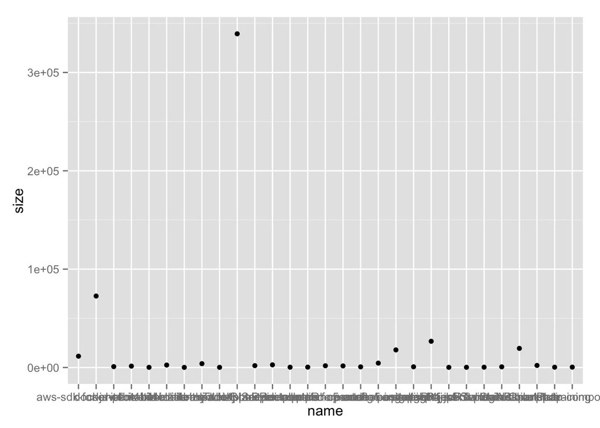

```r
#plot <- ggplot(json, aes(ssh_url, score)) + geom_point()
#print(plot)

plot <- ggplot(json, aes(name, size)) + geom_point()
print(plot)
```

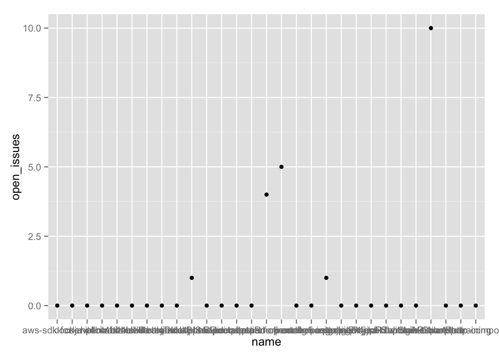

```r
plot <- ggplot(json, aes(name, open_issues)) + geom_point()
print(plot)
```

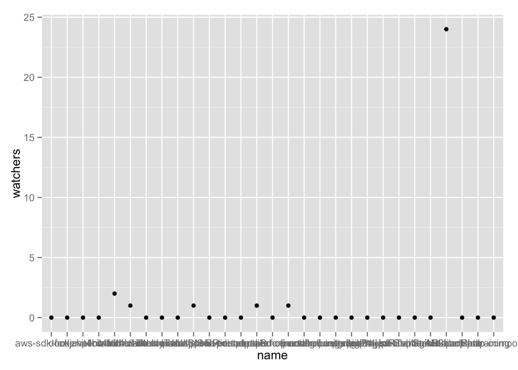

```r
plot <- ggplot(json, aes(name, watchers)) + geom_point()
print(plot)
```

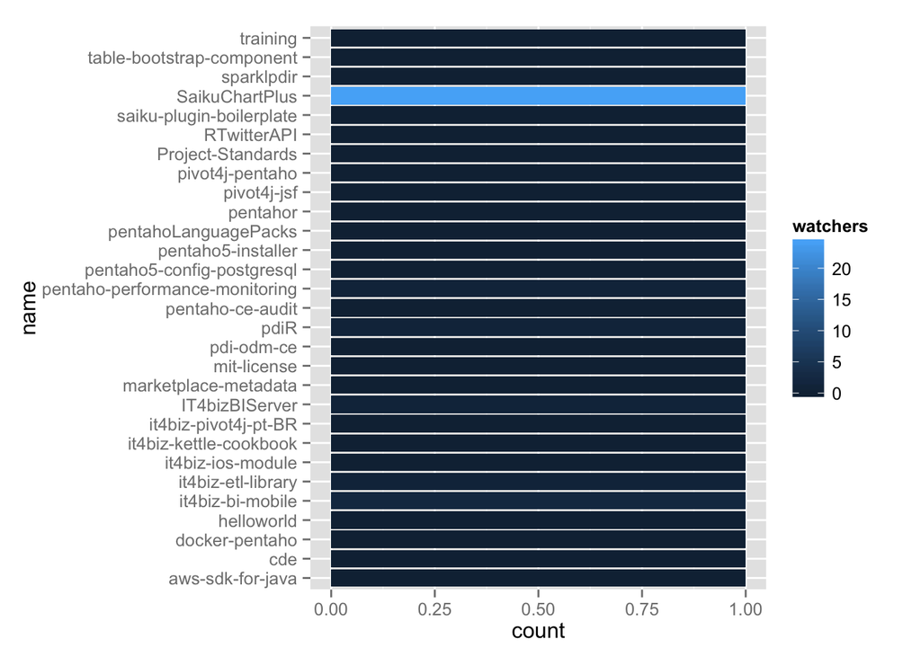

```r
ggplot(json, aes(name, fill=watchers)) + geom_bar() + coord_flip()
```

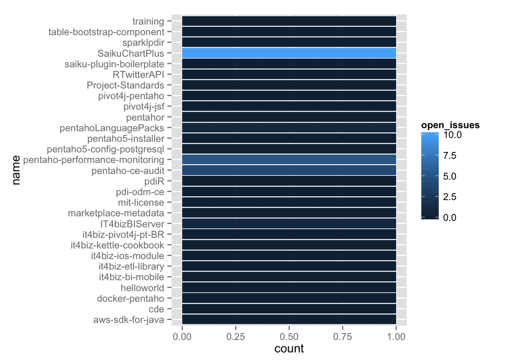

```r
ggplot(json, aes(name, fill=open_issues)) + geom_bar() + coord_flip()
```

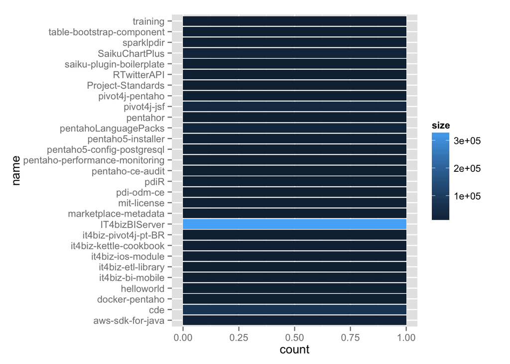

```r
ggplot(json, aes(name, fill=size)) + geom_bar() + coord_flip()
```

```r
#str(json)
#json

#colunas
#id
#full_name
#name
#created_at
#updated_at
#size
#watchers
#open_issues
#forks


#json[[1]]
#json[[2]]
#json[[3]]
#json[[4]]
#json[[5]]
#json[[6]]
#json[[7]]
#json[[8]]
#json[[9]]
#json[[10]]
#json[[11]]
#json[[12]]
#json[[13]]
#json[[14]]
#json[[15]]
#json[[16]]
#json[[17]]
#json[[18]]
#json[[19]]
#json[[20]]
#json[[21]]
#json[[22]]
#json[[23]]
#json[[24]]
#json[[25]]
#json[[26]]
#json[[27]]
#json[[28]]



names(json)
```

```
##  [1] "id"                "name"              "full_name"
##  [4] "owner"             "private"           "html_url"
##  [7] "description"       "fork"              "url"
## [10] "forks_url"         "keys_url"          "collaborators_url"
## [13] "teams_url"         "hooks_url"         "issue_events_url"
## [16] "events_url"        "assignees_url"     "branches_url"
## [19] "tags_url"          "blobs_url"         "git_tags_url"
## [22] "git_refs_url"      "trees_url"         "statuses_url"
## [25] "languages_url"     "stargazers_url"    "contributors_url"
## [28] "subscribers_url"   "subscription_url"  "commits_url"
## [31] "git_commits_url"   "comments_url"      "issue_comment_url"
## [34] "contents_url"      "compare_url"       "merges_url"
## [37] "archive_url"       "downloads_url"     "issues_url"
## [40] "pulls_url"         "milestones_url"    "notifications_url"
## [43] "labels_url"        "releases_url"      "created_at"
## [46] "updated_at"        "pushed_at"         "git_url"
## [49] "ssh_url"           "clone_url"         "svn_url"
## [52] "homepage"          "size"              "stargazers_count"
## [55] "watchers_count"    "language"          "has_issues"
## [58] "has_downloads"     "has_wiki"          "has_pages"
## [61] "forks_count"       "mirror_url"        "open_issues_count"
## [64] "forks"             "open_issues"       "watchers"
## [67] "default_branch"
```

```r
#names(json$owner)
#json$owner$login
#json$owner$watchers_count
#json$owner$size
#head(json)
#colnames(json)
```